# 第14回 グラフ作成②

プログラミング演習Ⅱ

佐藤 秀保

sato0035@toyo.jp

## 前回までの内容

- Pandasによるデータ加工
- maplotlibによる折れ線・棒グラフ作成

```python
#以下は実行不要
#データはアップロード済みと仮定
import pandas as pd
df = pd.read_csv("s2025_aki.csv")

#1.列名変更
df1 = df.rename(columns={"日付":"date",
                        "純売上":"sales",
                        "客数":"n_customers"}
                )

#2.列抽出
df1 = df1[["date", "sales", "n_customers"]]

#3.列追加（曜日）
df1["date"] = pd.to_datetime(df1["date"]) #datetime型に変換
df1["weekday"] = df1["date"].dt.day_name()
df1["weekday"] = df1["date"].dt.strftime("%a") #曜日表記変更

#4.並び替え（日付順）
df1 = df1.sort_values("date")

#5.欠損行削除（売上，客数）
df1 = df1.dropna(subset=["sales", "n_customers"])

#6.折れ線グラフ
plt.plot(
    df1["date"],
    df1["sales"],
    color="tab:blue",#色
    linestyle="--",#線のスタイル
    linewidth=2,#線の太さ
    marker="o" #データの点
)
plt.xlabel("Date")
plt.ylabel("Sales")
plt.title("Daily Sales")
plt.tight_layout()
plt.xticks(rotation=45)
plt.show()

#7.棒グラフ
##並び替え用リスト
order = ["Mon", "Tue", "Wed", "Thu", "Fri", "Sat", "Sun"]
##並び替え用曜日カテゴリ化
df_group["weekday"] = pd.Categorical(
    df_group["weekday"],
    categories=order,
    ordered=True
)
##並び替え（曜日順）
df_group = df_group.sort_values("weekday")

plt.bar(
    df_group["weekday"],
    df_group["sales"],
    color="lightgray",#塗りつぶし色
    edgecolor="blue",#枠線色
    hatch="//"#パターン
)
plt.xlabel("Weekday")
plt.ylabel("Average Sales")
plt.title("Average Sales by Weekday")
plt.tight_layout()
plt.show()
```

## 準備

1. [Colab](https://colab.research.google.com/?hl=ja).にアクセス
2. 左下「ノートブックを新規作成」
3. 左上のノートブック名を「lec14」などに変更
4. 右側に「リリースノート」が出る場合は×で消す
5. 朝霞キャンパス食堂のデータ読込
   - 2025年9月19日～12月22日の日別データから「日付」，「純売上」，「客数列」のみを抽出し，列名を`date`，`sales`，`n_customers`変更した後，曜日の列「`weekday`」を追加したデータ「2025_aki_clean.csv」をダウンロード

```python
from google.colab import files
uploaded = files.upload()
```

```python
import pandas as pd
df = pd.read_csv("s2025_aki_clean.csv")
#チラ見
df.head()
```

## 目的

- グラフ作成ができるようになる
  - **折れ線グラフ**：売上の推移
  - **棒グラフ**：売上の曜日別平均
  - **散布図**：売上・客数 ※今日
  - **ヒストグラム**：売上の分布 ※今日
  - **箱ひげ図**：売上の分布（曜日別も） ※今日

## 散布図

- ２変数の相関を視覚的に確認

### 基本１

- 文法：`plt.scatter(df["横軸の列名"], df["縦軸の列名"])`

```python
import matplotlib.pyplot as plt
plt.scatter(df["sales"], df["n_customers"])
plt.show()
```

### 基本２

- 軸ラベル：`xlabel`, `ylabel`
- タイトル：`title`
- 余白自動調整：`tight.layout`

```python
plt.scatter(df["sales"], df["n_customers"])

plt.xlabel("sales")
plt.ylabel("n_customers")
plt.title("Sales vs Number of Customers")
plt.tight_layout()

plt.show()
```

### 発展１

- 前回スライドで[色の例](https://hideyasusato.github.io/slides/program2_2025_lec13.html#/18)や[形の例](https://hideyasusato.github.io/slides/program2_2025_lec13.html#/19)を参照

```python
plt.scatter(
    df["sales"],
    df["n_customers"],
    color="tab:green",   # 色
    marker="^",         # 形
    s=40,               # 大きさ
    alpha=0.6           # 透明度
)

plt.xlabel("sales")
plt.ylabel("n_customers")
plt.title("Sales vs Number of Customers")
plt.tight_layout()

plt.show()
```

### 発展２

- 近似直線の追加
- 方針：
  1. 横軸・縦軸の値を`x`, `y`に保存
  2. 散布図を書く
  3. `x`, `y`から近似直線の**傾き**と**切片**を計算
  4. **傾き**，**切片**，`x`を用いて，**近似直線の高さ**`y_hat`を計算
  5. `x`, `y_hat`の折れ線グラフが近似直線

```python
import numpy as np

#方針1
x = df["sales"]
y = df["n_customers"]

#方針2
plt.scatter(df["sales"], df["n_customers"])

#方針3
#numpyの多項式当てはめ（polynominal fit）の関数
#1次式（直線）で当てはめ
#coefには傾き，切片が保存
coef = np.polyfit(x, y, 1)

#方針4
##coef,xからy_hatを計算
y_hat = np.poly1d(coef)(x)

#方針5
plt.plot(x, y_hat)

plt.show()
```

### 発展３

- 近似直線は折れ線グラフを重ねているだけなので，折れ線グラフをいじれば，[色](https://hideyasusato.github.io/slides/program2_2025_lec13.html#/18)や[線のスタイル](https://hideyasusato.github.io/slides/program2_2025_lec13.html#/17)も変更可

```python
import numpy as np
#方針1
x = df["sales"]
y = df["n_customers"]
#方針2
plt.scatter(df["sales"], df["n_customers"])
#方針3
coef = np.polyfit(x, y, 1)
#方針4
y_hat = np.poly1d(coef)(x)
#方針5
plt.plot(x, y_hat,
         color="red",      #色
         linestyle="-",   #スタイル
         linewidth=5)      #太さ

plt.show()
```

## ヒストグラム

- 変数の**完全な**分布を確認
- 変数が多くなる場合は箱ひげ図

### 基本１

- 文法：`plt.hist(df["列名"])`

```python
plt.hist(df["sales"])
plt.show()
```

### 基本2

```python
plt.hist(df["sales"])

plt.xlabel("sales")
plt.ylabel("frequency")
plt.title("Histogram of Sales")
plt.tight_layout()

plt.show()
```

### 発展１

前回のスライドで[パターン](https://hideyasusato.github.io/slides/program2_2025_lec13.html#/26)を参照

```python
plt.hist(
    df["sales"],
    bins=30,              # ビン（棒）の数
    edgecolor="black",    # 枠線
    color="green",        # 塗りつぶし色
    hatch="//",           # パターン
    alpha=0.7             # 透明度
)

plt.xlabel("sales")
plt.ylabel("frequency")
plt.title("Histogram of Sales")
plt.tight_layout()

plt.show()
```

### 発展２

- グループ別にヒストグラムを重ねる
  - 10月と11月で分布に違いはあるか比較
- 方針
  1. [`date`の型を`datetime`に変換](https://hideyasusato.github.io/slides/program2_2025_lec13.html#/%E6%96%B9%E9%87%9D3%E6%9B%9C%E6%97%A5%E3%81%AE%E5%88%97%E8%BF%BD%E5%8A%A0)
  2. `date`から`dt.month`メソッドで月にアクセスし，10月，11月の[条件を満たす行をそれぞれ抽出](https://hideyasusato.github.io/slides/program2_2025_lec10.html#/21)し，その`sales`列のみ抽出
  3. それぞれヒストグラムを作成

```python
#方針1
df["date"] = pd.to_datetime(df["date"])
#方針2
sales_10 = df[df["date"].dt.month == 10]["sales"]
sales_11 = df[df["date"].dt.month == 11]["sales"]
#方針3
plt.hist(
    sales_10,
    bins=15,              # ビン（棒）の数
    edgecolor="black",    # 枠線
    color="tab:blue",     # 塗りつぶし色
    alpha=0.7,            # 透明度
    label="October"       # 凡例
)
plt.hist(
    sales_11,
    bins=15,              # ビン（棒）の数
    edgecolor="black",    # 枠線
    color="tab:green",    # 塗りつぶし色
    alpha=0.7,            # 透明度
    hatch="//",           # パターン
    label="November"      # 凡例
)

plt.xlabel("sales")
plt.ylabel("frequency")
plt.title("Sales Distribution: October vs November")
plt.legend() #凡例の表示
plt.tight_layout()

plt.show()
```

### 演習１

- 10月，11月，12月の売上の分布を比較するヒストグラムを作成せよ
  - 色，パターン，透明度など自由にカスタマイズ
  - 違いはある？：中心の位置，バラツキ

## 箱ひげ図

- 変数の分布を確認（一部情報は落ちる）
- 変数が多いときみやすい

### 基本１

- 文法：`plt.boxplot(df["列名"])`

```python
plt.boxplot(df["sales"])
plt.show()
```

### 参考：箱ひげ図の見かた

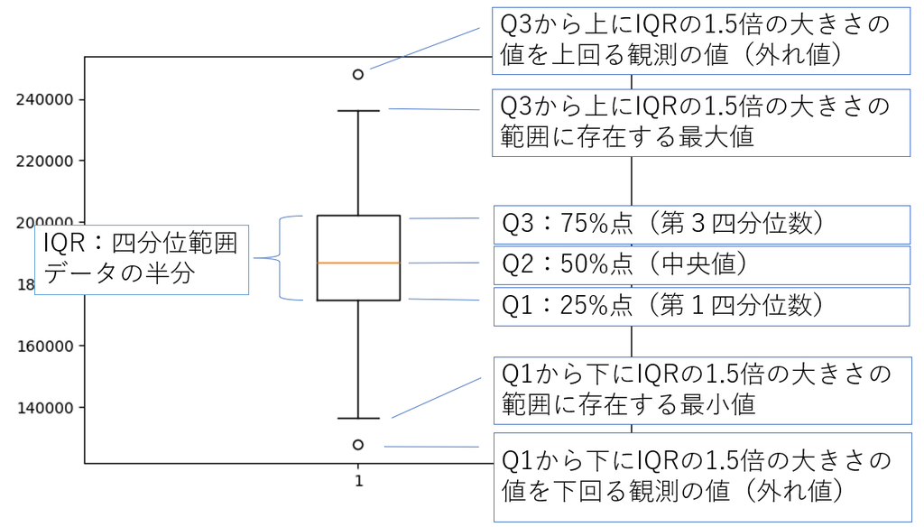

### 参考：ヒストグラムと箱ひげ図の対応

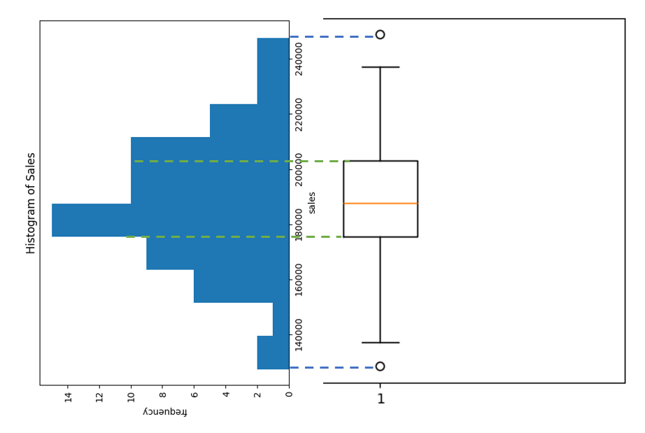

### 基本２

```python
plt.boxplot(df["sales"])

plt.ylabel("sales")
plt.title("Boxplot of Sales")
plt.tight_layout()

plt.show()
```

### 発展1

- 色，パターン，透明度などは図の部分ごとに「辞書」で指定
  - propsとは**prop**ertie**s**で属性の意

| 属性名 | 対象 |
| --- | --- |
| `boxprops` | 箱（Q1–Q3） |
| `medianprops` | 中央値の線 |
| `whiskerprops` | ひげ |
| `capprops` | ひげの端 |
| `flierprops` | 外れ値 |

### 発展1（つづき）

- `patch_artist = True`で事前に塗りつぶしを有効化
- `facecolor`：塗りつぶしの色，`color`：枠・線の色

```python
plt.boxplot(
    df["sales"],
    patch_artist=True,    #塗りつぶし有効化
    boxprops={"facecolor":"tab:blue", "alpha":0.6},
    medianprops={"color":"black", "linewidth":2},
    whiskerprops={"color":"black"},
    capprops={"color":"black"},
    flierprops={"marker":"o", "markerfacecolor":"gray", "alpha":0.5}
)

plt.ylabel("sales")
plt.title("Boxplot of Sales")
plt.tight_layout()
plt.show()
```

### 発展２

データを点で表示し散らすことで，より詳細な分布情報を追加

1. 箱ひげ図の縦軸の値を`y`に保存
2. 箱ひげ図作成
3. [ランダムに散らばった値を`y`の数だけ乱数で生成し`x`に保存](https://hideyasusato.github.io/slides/program2_2025_lec8.html#/18)
4. 箱ひげ図に点`(x,y)` を重ねる
- このようにずらした点は，jitterという

### 発展２（つづき）

```python
import numpy as np
y = df["sales"] #1
plt.boxplot(y) #2
x = np.random.normal(1, 0.05, size=len(y)) #3
plt.plot(x, y, "o", alpha=0.4)
#4:plotで"o"を指定すると，折れ線でなく点だけになる

plt.ylabel("sales")
plt.title("Boxplot of Sales (with jittered points)")
plt.tight_layout()
plt.show()
```

### 発展３

- グループ別の箱ひげ図を表示（10月vs11月）

```python
df["date"] = pd.to_datetime(df["date"])

sales_10 = df[df["date"].dt.month == 10]["sales"]
sales_11 = df[df["date"].dt.month == 11]["sales"]

plt.boxplot(
    [sales_10, sales_11],
    labels=["October", "November"]
)

plt.ylabel("sales")
plt.title("Sales Distribution: October vs November")
plt.tight_layout()
plt.show()
```

### 演習２

- 10月，11月，12月の売上の分布を比較する箱ひげ図を作成せよ
  - 色，jitterなど自由にカスタマイズ

### 参考：ヴァイオリン プロット

- 左右対称の分布として表現
- jitterと組み合わせて使用されることが多い

```python
plt.violinplot(df["sales"], showmedians=True)

plt.ylabel("sales")
plt.title("Violin Plot of Sales")
plt.tight_layout()
plt.show()
```

## まとめ

```python
#データはアップロード済みと仮定
import pandas as pd
df = pd.read_csv("s2025_aki_clean.csv")

#散布図
plt.scatter(df["sales"], df["n_customers"])
plt.xlabel("sales")
plt.ylabel("n_customers")
plt.title("Sales vs Number of Customers")
plt.tight_layout()
plt.show()

#散布図（色など変更）
import matplotlib.pyplot as plt
plt.scatter(
    df["sales"],
    df["n_customers"],
    color="tab:green",  # 色
    marker="^",         # 形
    s=40,               # 大きさ
    alpha=0.6           # 透明度
)
plt.xlabel("sales")
plt.ylabel("n_customers")
plt.title("Sales vs Number of Customers")
plt.tight_layout()
plt.show()

#散布図（近似直線）
x = df["sales"]
y = df["n_customers"]
plt.scatter(df["sales"], df["n_customers"])
coef = np.polyfit(x, y, 1)
y_hat = np.poly1d(coef)(x)
plt.plot(x, y_hat,
         color="red",      #色
         linestyle="-",   #スタイル
         linewidth=5)      #太さ
plt.show()

#ヒストグラム
plt.hist(df["sales"])
plt.xlabel("sales")
plt.ylabel("frequency")
plt.title("Histogram of Sales")
plt.tight_layout()
plt.show()

#ヒストグラム（色など変更）
plt.hist(
    df["sales"],
    bins=30,              # ビン（棒）の数
    edgecolor="black",    # 枠線
    color="green",        # 塗りつぶし色
    hatch="//",           # パターン
    alpha=0.7             # 透明度
)
plt.xlabel("sales")
plt.ylabel("frequency")
plt.title("Histogram of Sales")
plt.tight_layout()
plt.show()

#ヒストグラム（複数）
df["date"] = pd.to_datetime(df["date"])
sales_10 = df[df["date"].dt.month == 10]["sales"]
sales_11 = df[df["date"].dt.month == 11]["sales"]
plt.hist(
    sales_10,
    bins=15,              # ビン（棒）の数
    edgecolor="black",    # 枠線
    color="tab:blue",     # 塗りつぶし色
    alpha=0.7,            # 透明度
    label="October"       # 凡例
)
plt.hist(
    sales_11,
    bins=15,              # ビン（棒）の数
    edgecolor="black",    # 枠線
    color="tab:green",    # 塗りつぶし色
    alpha=0.7,            # 透明度
    hatch="//",           # パターン
    label="November"      # 凡例
)
plt.xlabel("sales")
plt.ylabel("frequency")
plt.title("Sales Distribution: October vs November")
plt.legend()
plt.tight_layout()
plt.show()

#箱ひげ図
plt.boxplot(df["sales"])
plt.ylabel("sales")
plt.title("Boxplot of Sales")
plt.tight_layout()
plt.show()

#箱ひげ図（色など変更）
plt.boxplot(
    df["sales"],
    patch_artist=True,    #塗りつぶし有効化
    boxprops={"facecolor":"tab:blue", "alpha":0.6},
    medianprops={"color":"black", "linewidth":2},
    whiskerprops={"color":"black"},
    capprops={"color":"black"},
    flierprops={"marker":"o", "markerfacecolor":"gray", "alpha":0.5}
)
plt.ylabel("sales")
plt.title("Boxplot of Sales")
plt.tight_layout()
plt.show()

#箱ひげ図（jitter）
y = df["sales"]
plt.boxplot(y)
x = np.random.normal(1, 0.05, size=len(y))
plt.plot(x, y, "o", alpha=0.4)
plt.ylabel("sales")
plt.title("Boxplot of Sales (with jittered points)")
plt.tight_layout()
plt.show()

#箱ひげ図（複数）
df["date"] = pd.to_datetime(df["date"])
sales_10 = df[df["date"].dt.month == 10]["sales"]
sales_11 = df[df["date"].dt.month == 11]["sales"]
plt.boxplot(
    [sales_10, sales_11],
    labels=["October", "November"]
)
plt.ylabel("sales")
plt.title("Sales Distribution: October vs November")
plt.tight_layout()
plt.show()
```

## 課題

- ACEの小テスト：「第14回」
- ACEのレポート：「第14回」
  - ノートブックを提出（方法は第１回資料参照）